# Reproducible Research: Peer Assessment 1

By Jawad Rashid

## Loading and preprocessing the data

### 1. Loading the data.

```r
data <- read.csv("activity.csv", stringsAsFactors = FALSE)
```

### 2. Converting the date to a valid R date object.

```r
data$date <- as.Date(data$date)
```

## What is mean total number of steps taken per day?

[figure not shown]

```r
hist(data$steps, xlab = "Total number of steps", main = "Total number of steps taken each day")
```

```r
mean(data$steps, na.rm = TRUE)
```

```
## [1] 37.38
```

```r
median(data$steps, na.rm = TRUE)
```

```
## [1] 0
```

## What is the average daily activity pattern?

### 1. Time series plot (i.e. type = “l”) of the 5-minute interval (x-axis) and the average number of steps taken, averaged across all days (y-axis)

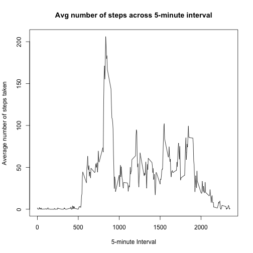

```r
averageStepsByInterval <- tapply(data$steps, data$interval, mean, na.rm = TRUE)
plot(names(averageStepsByInterval), averageStepsByInterval, type = "l", xlab = "5-minute Interval",
    ylab = "Average number of steps taken", main = "Avg number of steps across 5-minute interval")
```

### 2. 5-minute interval, on average across all the days in the dataset, contains the maximum number of steps?

```r
# Find the index and the maximum value
maxValues <- which.max(averageStepsByInterval)[1]
maxInterval <- names(which.max(averageStepsByInterval))
maxValue <- which.max(averageStepsByInterval)[[1]]
# Convert the interval from string to integer value
maxInterval <- strtoi(maxInterval, 10L)

maxInterval
```

```
## [1] 835
```

```r
maxValue
```

```
## [1] 104
```

## Imputing missing values

### 1. Total number of missing values in the dataset (i.e. the total number of rows with NAs)

```r
# Missing Values
missingValues <- is.na(data$steps)
table(missingValues)[[2]]
```

```
## [1] 2304
```

### 2. Strategy for filling in all of the missing values in the dataset is use the mean for the 5-minute interval.

```r
meanStepsByInterval <- tapply(data$steps, data$interval, mean, na.rm = TRUE)
naRows <- data[is.na(data), ]
for (i in 1:nrow(naRows)) {
    naRows[i, 1] <- meanStepsByInterval[[toString(naRows[i, 3])]]
}
```

### 3. Creating a new dataset that is equal to the original dataset but with the missing data filled in.

```r
filledInData <- data
filledInData[is.na(data), 1] <- naRows[, 1]
```

[figure not shown]

```r
hist(filledInData$steps, xlab = "Total number of steps", main = "Total number of steps taken each day")
```

```r
mean(filledInData$steps, na.rm = TRUE)
```

```
## [1] 37.38
```

```r
median(filledInData$steps, na.rm = TRUE)
```

```
## [1] 0
```

```r
averageStepsByIntervalForFilledData <- tapply(filledInData$steps, filledInData$interval,
    mean, na.rm = TRUE)
```